# ECON 214 Problem Set 1

Saurabh Khanna

2020-09-20

# Problem set 1

## Answer 1

### 1.1

Yet to answer

### 1.2

$$ln(gdp)_{i} = ln(lifeexp)_{i} + X_i + \epsilon_i$$
where $ln(lifeexp)_{i}$ is instrumented by $predictedmortality$, and $X_i$ indicates *country$\times$year* fixed effects.

The results from running our model are seen below.

```
##
## =========================
##                 Model 1
## -------------------------
## lifeexpectancy  -1.34 ***
##                 (0.36)
## -------------------------
## R^2              0.96
## Adj. R^2         0.92
## Num. obs.       94
## RMSE             0.27
## =========================
## *** p < 0.01; ** p < 0.05; * p < 0.1
```

### 1.3

```
##
## ================================================
##                 Asia    Latin America  Europe
## ------------------------------------------------
## lifeexpectancy  -5.73    0.24           2.33 ***
##                 (5.22)  (0.94)         (0.38)
## ------------------------------------------------
## R^2              0.70    0.94           0.99
## Adj. R^2         0.31    0.86           0.97
## Num. obs.       22      32             40
## RMSE             0.48    0.22           0.11
## ================================================
## *** p < 0.01; ** p < 0.05; * p < 0.1
```

### 1.4

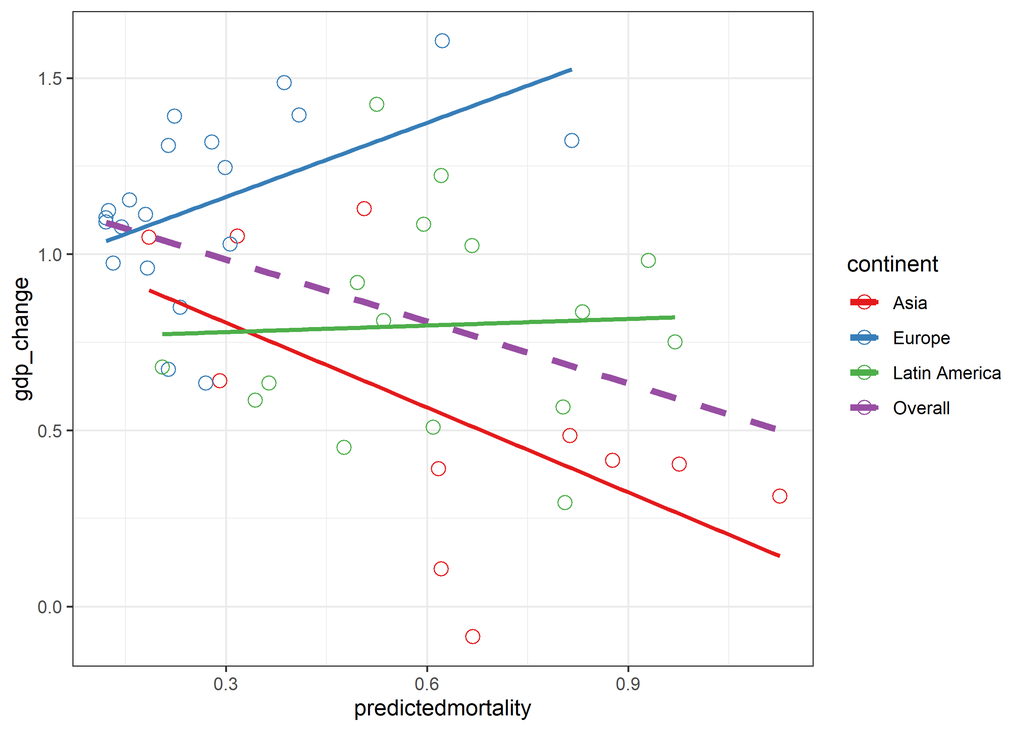

### 1.5

```
##
## =======================
##                 Model 1
## -----------------------
## lifeexpectancy   0.45
##                 (0.51)
## -----------------------
## R^2              0.81
## Adj. R^2         0.80
## Num. obs.       94
## RMSE             0.42
## =======================
## *** p < 0.01; ** p < 0.05; * p < 0.1
```

### 1.6

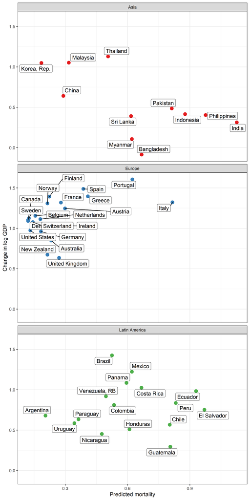

Yes, we can group by `initialincome`.

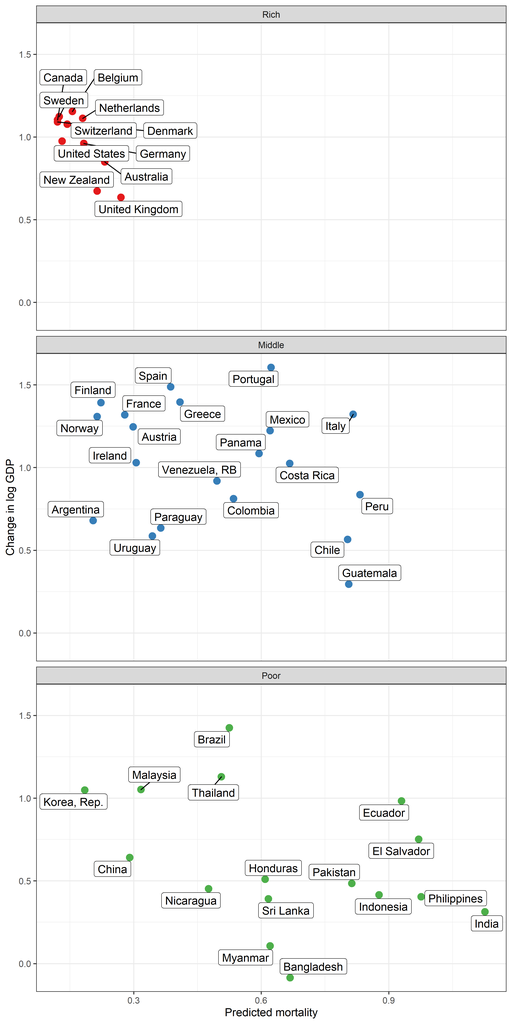

## Answer 2

### 1(a)

Yet to answer.

### 1(b)

Yet to answer.

### 2(a)

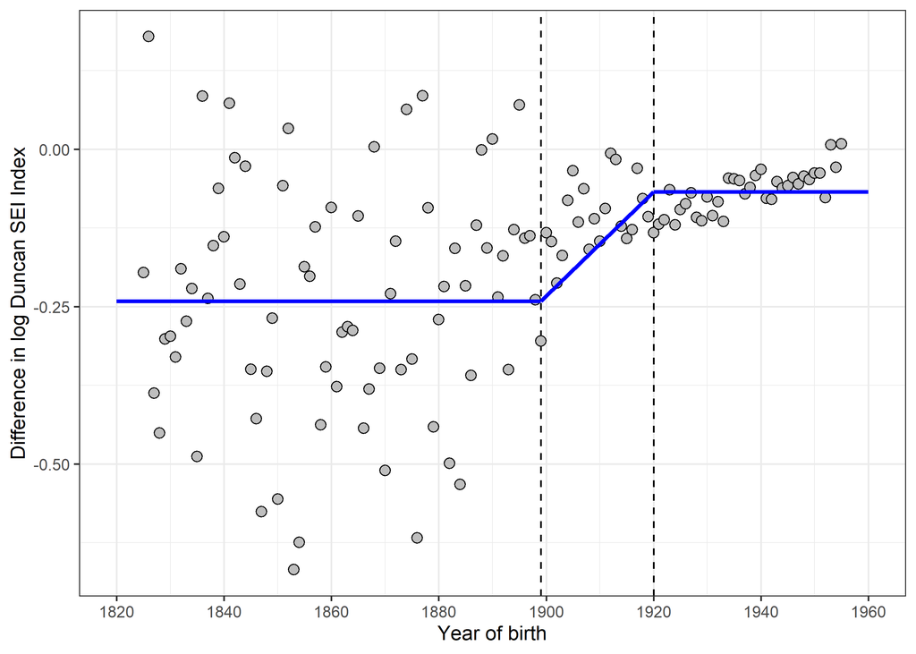

```
## # A tibble: 3 x 2
##   malaria_high     n
##   <lgl>        <int>
## 1 FALSE        10268
## 2 TRUE           914
## 3 NA             259
```

```
## # A tibble: 3 x 2
##   malaria_low     n
##   <lgl>       <int>
## 1 FALSE       10298
## 2 TRUE          884
## 3 NA            259
```

### 2(b)

Those born between 1899 and 1920 should be excluded.

```
##
## ===================================================================
##                         Duncan SEI Index  Occupational Income Score
## -------------------------------------------------------------------
## (Intercept)                3.36 ***          3.18 ***
##                           (0.07)            (0.05)
## malaria_highTRUE          -0.24 **          -0.18 ***
##                           (0.07)            (0.05)
## young                      0.35 ***          0.17 ***
##                           (0.06)            (0.04)
## malaria_highTRUE:young     0.16 **           0.14 **
##                           (0.07)            (0.04)
## -------------------------------------------------------------------
## R^2                        0.41              0.39
## Adj. R^2                   0.41              0.39
## Num. obs.               1459              1459
## RMSE                       0.28              0.17
## N Clusters                 8                 8
## ===================================================================
## *** p < 0.01; ** p < 0.05; * p < 0.1
```

### 2(c)

Standard errors are clustered at the state of birth level.

### 2(d)

For the results of this study to be internally valid, the identification strategy needs the parallel trend assumption to hold. It requires that in the absence of treatment, the difference between the treatment and control groups is constant over time.

### 2(e)

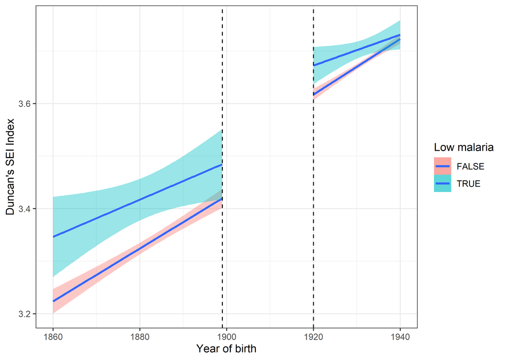

### 2(f)

```
##
## ==============================================================
##                    Duncan SEI Index  Occupational Income Score
## --------------------------------------------------------------
## (Intercept)           3.28 ***          3.14 ***
##                      (0.02)            (0.02)
## malmort1890          -0.20 ***         -0.18 ***
##                      (0.05)            (0.04)
## young                 0.45 ***          0.22 ***
##                      (0.02)            (0.01)
## malmort1890:young     0.13 ***          0.14 ***
##                      (0.04)            (0.03)
## --------------------------------------------------------------
## R^2                   0.68              0.63
## Adj. R^2              0.68              0.63
## Num. obs.          9107              9107
## RMSE                  0.69              0.43
## N Clusters           49                49
## ==============================================================
## *** p < 0.01; ** p < 0.05; * p < 0.1
```

| bplg | observations |
| --- | --- |
| 5 | 196 |
| 25 | 200 |
| 27 | 190 |
| 28 | 200 |
| 40 | 151 |
| 48 | 199 |
| 50 | 200 |
| 56 | 126 |

### 2(g)

Omitted variable bias.

## Answer 3

### 3(a)

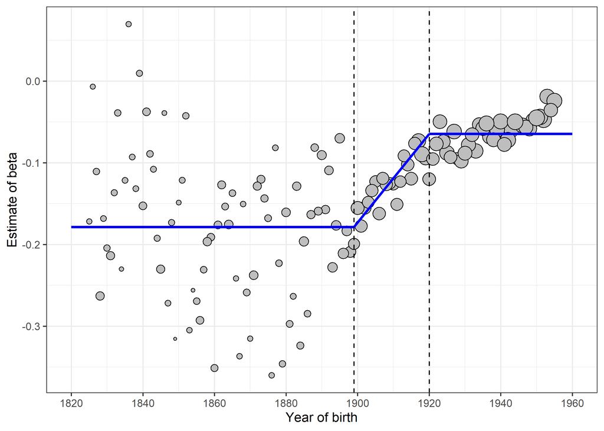

For the intervening cohorts, who had inter-mediate levels of childhood exposure to the campaign, pre-campaign malaria pre-dicts lower income, but with magnitude that diminishes for later birth years. This is also consistent with the childhood-exposure model, insofar as partial exposure to the campaign confers partial benefits to these middling cohorts.

### 3(b)

```
##
## ===============================================
##                      Model 1       Model 2
## -----------------------------------------------
## exp_mal
##
## malmort1890             -0.23 ***     -0.10 *
##                         (0.05)        (0.06)
## bplg                    -0.01
##                         (0.02)
## yob
##
## year                    -0.00
##                         (0.00)
## exp_mal:malmort1890      0.15 ***      0.12 ***
##                         (0.04)        (0.03)
## bplg:yob                 0.00
##                         (0.00)
## -----------------------------------------------
## R^2                      0.76          0.78
## Adj. R^2                 0.76          0.78
## Num. obs.            11165         11165
## RMSE                     0.55          0.53
## N Clusters              49            49
## ===============================================
## *** p < 0.01; ** p < 0.05; * p < 0.1
```